# PII: S0149-2063(00)00065-9

Converted from PDF `Iverson-TurnoverLayoffsAfterMerger-2000-JOM.pdf` · 27 pages · anchors: page `#pN`, block `#pN-bK`

Page 1

### *Determinants of Voluntary Turnover and*

### *Layoffs in an Environment of Repeated*

### *Downsizing Following a Merger:*

### *An Event History Analysis<sup>1</sup>*

Roderick D. Iverson Jacqueline A. Pullman

*University of Melbourne*

*In this study we formulate and test models of voluntary turnover and downsizing in a hospital undergoing workforce reduction following a merger. Targeted separation packages were primarily employed by the hospital in selecting departments and units as having surplus staff, as well as identifying individual employees. Determinants for the models were derived from the disparate disciplines of economics, sociology, and psychology, as well as demographic and reactions to change variables. Applying event history analysis to data from a sample of 415 hospital employees over a five year period, the results indicate that older, full-time employees, who were less absent, and had an acceptable workload, yet experienced lower co-worker support and responded negatively to the amalgamation of the hospital were more likely to be downsized. Conversely, employees who were younger, white-collar, intended to leave, and predisposed to the amalgamation were more likely to resign. In addition, the differential effects (based on discriminant function analysis) of the five categories of variables found that age, blue-collar, co-worker support, full-time, amalgamation, and work overload discriminated between the two forms of turnover. The theoretical and practical implications of the findings are discussed. © 2000 Elsevier Science Inc. All rights reserved.*

Hom and Griffeth (1995) note that despite the fact that turnover has been studied since the turn of the century, it has only been over the last 40 years that major conceptual models have been developed (e.g., March & Simon, 1958; Price, 1977; Mobley, Griffeth, Hand, & Meglino, 1979). Unfortunately the majority of these models concentrated on voluntary turnover (e.g., resignation) with little regard to involuntary turnover (e.g., dismissals and layoffs). In this paper we

Direct all correspondence to: Roderick D. Iverson, Department of Management, University of Melbourne, Parkville, Victoria, AUSTRALIA 3010, E-mail: r.iverson@unimelb.edu.au

Journal of Management 2000, Vol. 26, No. 5, 977–1003

#### **Copyright © 2000 by Elsevier Science Inc. 0149-2063**

977

Page 2

focus on layoffs and not dismissals. As will be discussed later, although layoffs and dismissals are dimensions of involuntary turnover, they are considered to have different determinants (Abelson, 1987; Campion, 1991). With around two in every three Australian organizations downsizing (Dawkins, Littler, Valenzuela, & Jensen, 1999), an estimated 43 million jobs being shed in the United States since the 1980s (Uchitelle & Kleinfield, 1996), 9 million jobs lost in Britain since 1995 (Dillon, 1997) and researchers advocating “best practice” methods for effective downsizing (Cameron, Freeman, & Mishra, 1991; Mishra, Spreitzer, & Mishra, 1998) it would appear that a greater understanding of involuntary turnover is warranted. Barrick, Mount, and Strauss (1994), in fact, note that the sparsity of research on involuntary turnover due to workforce reduction is “somewhat surprising since the firm’s choice of who should leave may have as large an impact on organizational effectiveness as the employee’s choice to leave” (p. 515). In this study we examine the antecedents of both voluntary turnover and layoffs in a public hospital undertaking repeated downsizing. Importantly, this is undertaken following the merger of two hospitals. We provide a brief discussion of the implications of employing downsizing as a source of competitive advantage.

#### **Downsizing: Benefits, Trends and Process**

*Competitive Advantage*

The search for competitive advantage has led organizations to become more efficient and flexible in their utilization of human resources. Over the last two decades a common organizational response has been to reduce workforce numbers through downsizing (Brockner, 1988; Cascio, Young, & Morris, 1997). Organization downsizing involves “the planned elimination of positions or jobs” and can incorporate workforce reduction, work redesign and systematic change (Cascio, 1993, p. 96). Its prevalence in management literature and research since the 1980’s has stemmed from many organizations using downsizing as a tool to cut costs, and/or to improve profitability, share prices and productivity (Mone, 1994). Moreover, the increasing trend to put CEOs and senior managers on short-term contracts has added pressure on them to achieve short-term gains (Kets de Vires & Balazs, 1997). Nevertheless, there is current evidence to suggest that the much sought after cost reductions and increased efficiencies have not materialized (Cameron, 1998; Ebadan & Winstanley, 1997). One explanation stems from the process of how organizations decide which positions or jobs to eliminate. It is entirely possible that organizations may inadvertently target jobs or offer redundancy packages to employees who have key organizational competencies and/or be high performers (e.g., dysfunctional turnover) (Cameron et al., 1991; Campion, 1991). The aim of the present study is therefore to provide a better understanding of the processes involved in downsizing. To do this we analyze the antecedents derived from the economic, sociological, and psychological literature, as well demographic and reactions to change variables that serve to differentiate between employees who resign and those who are laid-off (i.e., offered redundancy packages). We outline the downsizing trends in Australia and overseas to

978 R.D. IVERSON AND J.A. PULLMAN

JOURNAL OF MANAGEMENT, VOL. 26, NO. 5, 2000

Page 3

highlight the complexity of attempting to implement workforce reduction strategies.

*Downsizing Trends*

Although the adoption of downsizing in Australia and New Zealand is a more recent phenomenon, the impact has been no less severe than experienced in the United States. Between 1993 and 1995, 57% and 48% of Australian and New Zealand organizations, respectively, downsized employees (Littler, Dunford, Bramble, & Hede, 1997). In Australia this trend actually increased in the late 1990s, with 62% of organizations reporting they downsized during the period of 1997–1998. (Dawkins et al., 1999). Some 36% of these organizations had downsized once, 30% on two occasions, and 34% had downsized three or more times (Dawkins et al., 1999). Moreover, the Australian Bureau of Statistics (ABS) (1998) estimated that of all employees who have held a job in the three years to 30 June 1997, 7% or 685,400 employees had been retrenched or made redundant on one or more occasions during this period. Consistent with overseas trends in the health care industry, the hospital in the present study downsized four separate times during the study period (Luthans & Sommer, 1999). We follow a sample of hospital workers for five years proceeding the administration of the questionnaire to investigate whether a common set of factors account for layoffs and the voluntary turnover of employees using the statistical procedure of event history analysis. To understand the downsizing strategies implemented by the hospital we provide a brief overview of the process.

*Downsizing Process*

The public hospital commenced operations in 1991 as a result of a merger between two local hospitals. This required the amalgamation of all hospital services and a change in the traditional structure of medical, nursing, and administration to a matrix structure of programs. State and Federal governments in early 1990s changed the healthcare funding formula which resulted in budget cuts to the hospital. In response to these cuts the hospital sought and achieved major cost savings through workforce restructuring, particularly in the area of support services (e.g., food, car fleet, gardening). Of the original sample of 415 employees we surveyed in November 1992, only 194 remained by November 1997. Workforce reduction was primarily involuntary by means of targeted separation packages.<sup>2</sup> This involved the selection and identification of departments and units as having surpluses, as well as the targeting of individual employees. The severance package entitled employees to 2 weeks of pay per every year of service up to a maximum of 10 years. Employees were also entitled to an additional 4 weeks of pay, accrued annual and long-service leave (3 months leave after 10 years of tenure). The maximum for the targeted separation package was 24 weeks pay, plus accrued annual and long-service leave entitlements.<sup>3</sup> Part of the targeted approach was 13 weeks of redeployment which if not possible was also paid to the employee. Unfortunately, this engendered a “package culture”, whereby some employees requested to be made redundant only if they could receive a package. However, these employees tended to be in areas that were not targeted. As a

979 DETERMINANTS OF VOLUNTARY TURNOVER AND LAYOFFS AFTER A MERGER

JOURNAL OF MANAGEMENT, VOL. 26, NO. 5, 2000

Page 4

consequence, some employees wanted to leave but could not afford to, while others left because they could afford to, but not because they wanted to.

The merger to form the present hospital represents what Lee and Mitchell (1994) characterize as a *shock*. A shock refers to an “event that jars employees toward deliberate judgements about their jobs” (Lee & Mitchell, 1994, p.60). These judgments may lead employees to either stay or leave their jobs (Lee, Mitchell, Wise, & Fireman, 1996; Lee, Mitchell, Holtom, McDaniel & Hill, 1999). Importantly, shocks can be expected or unexpected, as well as having negative, neutral or positive affects for employees. In this study, we predict how long employees stay or leave after the shock of the merger. This contributes to our understanding of how employees cope with change and the behavioral consequences (e.g., turnover) that may result.

#### **Voluntary and Involuntary Turnover**

As raised earlier in the paper, there is debate in the literature regarding the meaning and measurement of turnover (Abelson, 1987; Campion, 1991). This especially applies to the concept of involuntary turnover. In the present study we classify employees retrenched as involuntary turnover (Price, 1977) and those employees who resign (and not offered packages) as voluntary turnover (Price, 1977). Abelson (1987) classified turnover due to layoffs (i.e., reduction in workforce) and dismissals as different forms of involuntary turnover. This classification was again supported by Campion’s (1991) empirical work. Examining turnover data of former employees, and supervisors, as well as the organization’s personnel files, Campion concluded that turnover due to reduction in force be “viewed as involuntary” (p. 206). Nevertheless, layoffs should not be equated with dismissals, as the former is driven by the economic necessity to cut costs and improve efficiency, while the latter is linked with the poor job performance of employees. Bycio, Hackett, and Alvares (1990), for example, in meta-analysis of 45 studies observed an average corrected correlation of *rc* 5 2.52 between involuntary turnover (dismissals) and job performance. In our study, employees who voluntarily left for reasons other than job related (e.g., spouse moving) were deleted from the analysis as it was deemed to be beyond the control of the employee and the organization (i.e., unavoidable turnover) (Abelson, 1987; Shaw, Delery, Jenkins, & Gupta, 1998). Unfortunately, we are not able to conclusively determine from personnel records whether the turnover was functional (e.g., low performers) or dysfunctional (e.g., high performers) (Dalton, Todor, & Krackhardt, 1982). Although we did collect absenteeism data, our focus was on predicting layoffs and not dismissals. To untangle this complex turnover taxonomy, we draw on three disparate disciplines and a set of determinants derived from turnover research.

#### **Theoretical Perspectives**

Although models of voluntary turnover are well established, the same cannot be said for involuntary turnover such as downsizing (Hom & Griffeth, 1995). We

980 R.D. IVERSON AND J.A. PULLMAN

JOURNAL OF MANAGEMENT, VOL. 26, NO. 5, 2000

Page 5

could only locate the study by Barrick et al. (1994) which formulated a model of involuntary turnover in an environment of workforce reduction. To address this deficiency we adopt a multi-disciplinary approach (Hom & Griffeth, 1995; Iverson & Roy, 1994; Maertz & Campion, 1998; Mueller & Price, 1990; Shaw et al., 1998). Variables are included from the disciplines of economics, psychology, and sociology, as well as demographic and reactions to change variables. These variables were selected based on their theoretical relevance, empirical support in the literature, and appropriateness to the research setting and sample studied. Mueller and Price (1990) note that recently, “organizational and industrial psychologists have challenged the strict economic explanation by developing models that key more on employee orientations and the decision making processes that lead to turnover” (p. 322). Sociologists integrate concepts by economists and psychologists and add structural variables (e.g., job related) in their explanation of employee turnover. In our model, we also include personal characteristics of employees, as well as their reaction to the hospital amalgamation. We propose these five sets of variables to differ in their importance in predicting the two forms of turnover. As cost savings characterized the merger and downsizing of the hospital, we expect the demographic (e.g., age) and economic variables (e.g., absenteeism) to be more salient in predicting employee layoffs. In contrast, we anticipate the sociological (e.g., distributive justice), psychological (e.g., intent to leave), and reactions to change variables to be better predictors of voluntary turnover. There is an abundance of evidence supporting the role of job related factors, employee orientations and acceptance of change in explaining employees’ resignation decisions (Hom & Griffeth, 1995; Lee et al., 1996; Mueller & Price, 1990; Price & Mueller, 1986). We elaborate on these variables in the following sections.

*Demographic Variables*

The first group of variables refer to the individual attributes that employees bring to the hospital. As posited above, we expect personal characteristics to better predict layoffs than resignations due to the targeted approach taken by the hospital.<sup>4</sup> *Age* has been found to have a negative relationship with voluntary turnover (Cotton & Tuttle, 1986; Somers, 1996). That is, younger employees are more likely to initiate leaving the organization. This is consistent with the side-bets or sunk costs argument that older employees have more investments (e.g., superannuation, skills, knowledge) which lock them in the organization (Meyer & Allen, 1997). At the same time, as these older employees tend to earn higher wages, they are more likely to be laid-off in order to reduce labor costs (Barrick et al., 1994).

Although Hom and Griffeth (1995) in a meta-analysis of 15 studies (*N* 5 6,748) observed that *females* were no more likely to voluntary leave than males, an earlier meta-analysis by Cotton and Tuttle (1986) reported females were more likely to resign. In the present study we anticipate a positive relationship (Cohen, 1999). As females are over-represented in white-collar occupations (e.g., nurses) (to be discussed later in this section), we expect them to have greater job opportunities outside the hospital and therefore to resign more often (Price &

981 DETERMINANTS OF VOLUNTARY TURNOVER AND LAYOFFS AFTER A MERGER

JOURNAL OF MANAGEMENT, VOL. 26, NO. 5, 2000

Page 6

Mueller, 1986). Conversely, we hypothesize a negative relationship with layoffs. Barrick et al (1994), for example, in a study of downsized salespeople reported *females* were less frequently retrenched than males. As males tend to be overrepresented in support services (e.g., gardening) and as these services were targeted first, it is reasonable to expect that more males than females would be laid-off.

In terms of employment status, *full-time* hospital employees have been observed to display a negative relationship with voluntary turnover (Mueller, Price, & Iverson, 1989; Price & Mueller, 1986). Nonetheless, as cost-cutting underpinned the workforce reduction strategy in the hospital, we expect that *full-time* employees would be more frequently downsized than part-time employees.

Despite the fact that Price (1977) in a codification of the literature concluded that *blue-collar* employees were generally more likely to voluntarily leave than white-collar employees, we hypothesize the reverse. This is due to the climate of cost-cutting at the hospital. By focusing on increasing efficiencies in support services such as cleaning and food, it was anticipated that *blue-collar* employees would be more likely to be downsized. In contrast, white-collar employees because of their employability (Price & Mueller, 1986) would tend to resign. Moreover, as the downsizing process engendered a ‘package culture’, there was a reluctance of blue-collar employees to resign in the event that they may be offered a redundancy package.

*Economic Variables*

The economic perspective (e.g., Becker, 1964; Burton & Parker, 1969; Viscusi, 1979; Williamson, 1975) focuses on the rational cost-benefit assessment of organizations and employees (Mueller & Price, 1990; Shaw et al., 1998). If the benefits to costs ratio of staying at the hospital outweigh the same ratio at another organization, the employee will not voluntarily leave. From the perspective of the organization, a cost-benefit evaluation of each employee is also undertaken. An employee is more likely to be laid-off when an organization considers that its investments in and costs of retaining the employee outweigh the human capital of that employee. Hence, in the present setting, we posit the economic variables to display a more important relationship with layoffs than with voluntary turnover.

A dominant variable for economists is that of *education*. It reflects the human capital of employees (Becker, 1964; 1975) and is argued to increase mobility in the labor market (Iverson & Buttigieg, 1999). There is support in the literature for the positive impact on voluntary turnover (Cotton & Tuttle, 1986; Hom & Griffeth, 1995). We also expect *education* to have a negative relationship with downsizing given that organizations seek to retain employees with greater human capital (Becker, 1975). This is consistent with our previously hypothesis relating to white-collar employees.

The second variable, *job opportunity*, refers to the availability of jobs outside the organization (Price & Mueller, 1986). The supply and demand created by the job market either restricts or enhances the movement of employees. Therefore the greater the job opportunities, the greater the voluntary turnover (Mueller, Price,

982 R.D. IVERSON AND J.A. PULLMAN

JOURNAL OF MANAGEMENT, VOL. 26, NO. 5, 2000

Page 7

Boyer, & Iverson, 1994). In contrast to the common belief, at the macro-level downsizing is positively linked with upturns in the business cycle on the expectation of impending downturns (Budros, 1997). However, at the micro-level of the employee, it is plausible to hypothesize a negative relationship. Congruent with human capital theory (Becker, 1964; 1975), organizations may seek to retain employees who may be lured away by alternative employment prospects. Moreover, it is also plausible that employees perceiving there to be low alternatives may be more vulnerable to downsizing due to their position (e.g., support services) in the hospital.

*Promotional opportunity* is defined as the degree of movement between status levels in an organization (Martin, 1979). It relates to the internal labor market of organizations and has been linked with lower voluntary turnover (Stumpf & Dawley, 1981). We also expect a negative relationship with downsizing. Following the merger and restructuring (e.g., delayering) of the hospital, we anticipate that employees who consider there to be limited promotional opportunities are more likely to by laid-off (e.g., blue-collar employees). A critical factor for economists is that of *pay*, which is considered a primary motivator for employees (Mueller & Price, 1990). If pay is seen to be higher in the present job than others in the labor market then voluntary turnover is reduced (Mueller et al., 1989; 1994). Nonetheless, as these same employees represent costly labor it is reasonable to expect that they are more vulnerable to layoffs. As we control for the demographic effects of age, employment status (full- or part-time), and occupation (i.e., blue- or white collar) and the human capital variable of education (see Trevor, Gerhart, & Boudreau, 1997 for a comparable strategy), we hypothesize a positive relationship between pay and downsizing.

*Absenteeism* refers to the non-attendance of employees for scheduled work (Johns, 1978; Chadwick-Jones, Nicholson, & Brown, 1982). We focus on avoidable absenteeism as measured by the frequency of one and two days non-certified (medical certificate not supplied) absence. This measure is generally agreed to be associated with an employee’s motivation to attend to work (Brooke & Price, 1989). Both meta-analyses of Mitra, Jenkins, and Gupta (1992) and Hom and Griffeth (1995) report a significant positive relationship between absenteeism and voluntary turnover (i.e., *rc* 5 .33). Employees engage in absenteeism (i.e., temporary withdrawal) behavior before progressing to voluntary leaving the organization (Rosse´ & Miller, 1984). In relation to downsizing, we also expect a positive relationship. As absenteeism has an inverse relationship with job security (Iverson, Deery, & Erwin, 1995), the motivation to attend work should be enhanced due to the fear of losing one’s job from the merger. Moreover, as absenteeism is a major cost to organizations (Rhodes & Steers, 1990), there would be an increased impetus to target areas and employees with unacceptable levels.

In a meta-analysis of nine studies, Cotton and Tuttle (1986) found a significant negative relationship between the presence of a union and voluntary turnover. This finding is consistent with the exit-voice hypothesis (Freeman, 1980), which asserts that although *union members* voice greater job dissatisfaction they are less likely to leave than non-members. Moreover, as a basic objective of unions is to protect the interests of their members such as job security (Barling,

983 DETERMINANTS OF VOLUNTARY TURNOVER AND LAYOFFS AFTER A MERGER

JOURNAL OF MANAGEMENT, VOL. 26, NO. 5, 2000

Page 8

Fullagar, & Kelloway, 1992), we predict union members would be less likely to be laid-off.

*Sociological Variables*

The third group of variables, sociological, (e.g., Price, 1977; Price & Mueller, 1981, 1986) stress the structural dimension relating to the work setting and environment. As previously outlined, sociologists build on both the economic and psychological models (Mueller & Price, 1990). This approach basically argues that there are specific working conditions that employees find attractive, which if not present will induce employees to leave. Given the changes that were taking place in the hospital, we argue that the following factors will be better predictors of voluntary turnover than layoffs.

*Job security* refers to the extent to which an organization provides stable employment for employees (Herzberg, 1968). Mobley (1982) noted that organizations that experience fluctuations in employment levels may find it difficult to retain employees due to fear of retrenchments. Hence, following the merger, we anticipate that employees experiencing lower job security are more likely to be both made redundant and voluntary leave due to their position in the hospital.

The social support variables of *coworker* (degree of consideration expressed by coworkers) (Blau, 1960) and *supervisory support* (degree of consideration expressed by immediate supervisor for subordinates) (Michaels & Spector, 1982) derive from an employee’s social network. They are important in buffering job stress (House, 1981) and reflect dimensions such as caring about the welfare of employees and listening to job related problems. It is posited that social support will be associated with lower voluntary turnover (Price & Mueller, 1986). In terms of layoffs, Armstrong-Strassen (1998) notes that employees when faced with uncertainty (e.g., following a merger) engage in various coping behaviors. One such strategy is that of help-seeking coping which involves seeking assistance or support from others. Alternatively, employees perceiving themselves to be potential ‘victims’ of the restructuring may cope by blaming others (e.g., coworkers and supervisors) for their situation (Cameron, 1994; Leana & Feldman, 1990). In any event, we predict a negative relationship between social support and downsizing.

The two job stress variables of *work overload* (extent to which the job performance required in a job is excessive) (Iverson et al., 1995) and *role overload* (extent to which employees lack the necessary skills to deal with the requirements of their jobs) (Iverson et al., 1995) are expected to display relationships with both types of turnover. Hom and Griffeth (1995) in a meta-analysis observed a moderate positive correlation (*rc* 5 .11) between role overload and voluntary turnover, while Mueller et al. (1994) reported work overload to have significant positive total effects on voluntary turnover. We hypothesize differential effects of these two stress variables for layoffs. Greenhalgh and Rosenblatt (1984) suggest that in an environment of job insecurity it is “rational for employees who feel insecure to exert more effort in order to become more valuable to the organization . . . ” (p. 443). Hence, a negative relationship is anticipated. Conversely, as the duties and responsibilities of jobs tend to be enlarged following

984 R.D. IVERSON AND J.A. PULLMAN

JOURNAL OF MANAGEMENT, VOL. 26, NO. 5, 2000

Page 9

organizational restructuring (Iverson, 1996), generally without the accompanying training (Bencivenga, 1997), we predict a positive relationship between role overload and layoffs.

*Psychological Variable*

The psychological perspective (e.g., March & Simon, 1958; Mobley, 1977, 1982; Porter & Steers, 1973; Vroom, 1964) in contrast to the economic perspective focuses on the cognitive evaluations of employees (Mueller & Price, 1990). Employees have specific expectations regarding the organization and job. Rather than focus on the cost-benefit approach of the economists, psychologists conceptualize in terms of rewards and punishments (or costs) (Farrell & Rusbult, 1981). The variable of *intention to leave* is dependent on whether employees expectations have been met since entering the hospital (Vroom, 1964). This employee orientation refers to the behavioral attachment to the organization (Iverson & Roy, 1994). There is abundance of evidence to support that intent to leave is one of the best predictors of voluntary turnover (Hom & Griffeth, 1995; Mueller et al., 1994; Price & Mueller, 1986). Accordingly, we hypothesize a positive relationship between intent to leave and voluntary turnover. A similar relationship is also posited for layoffs. Following the merger, employees may view this as an opportunity to pursue other career interests outside the hospital. Bennet, Martin, Bies, and Bruckner (1995) classify this as problem-focused coping, which rather than being a negative may be a positive reaction to the shock. In addition, due the possibility of receiving a fairly generous redundancy package, the willingness to quit of employees may be heightened.

*Reactions to Change Variable*

In the present study, the change variable related to the *amalgamation* that occurred in forming the current hospital. Respondents were asked whether the hospital was a better place to work since the amalgamation. We hypothesize that employees who respond negatively to the changes are more likely to voluntarily leave the hospital (Greenhalgh & Rosenblatt, 1984). Employees whose jobs are less affected by the merger are also argued to be less vulnerable to downsizing. In this situation, we consider that these employees would rate the change more favorably than employees who had their jobs redesigned (e.g., enlarged). Therefore, a negative relationship is predicted.

As previously outlined, we provide an exploratory model of voluntary turnover and layoffs based on the demographic, economic, sociological, psychological, and reactions to change variables. A summary of hypotheses are presented in Table 1. In the following section we describe the methodology employed before proceeding to the Results section.

#### **Methods**

*Research Setting*

The setting for this research is a large public hospital specializing in geriatric care. The hospital is located in the state of Victoria, Australia. At the time of the survey the hospital employed approximately 2,000 people.

985 DETERMINANTS OF VOLUNTARY TURNOVER AND LAYOFFS AFTER A MERGER

JOURNAL OF MANAGEMENT, VOL. 26, NO. 5, 2000

Page 10

*Sample*

*Data Collection*

A multiple-item survey measure was administered during working hours in November 1992 to a random sample of 740 employees at the hospital. The survey was administered approximately two weeks before the first lot of redundancies were announced. In a covering letter, respondents were informed of the purpose of the study stressing that participation was voluntary and that all information collected was confidential. The response rate was 64% (*N* 5 473). Following the matching of respondents to their personnel records and the listwise deletion of missing data procedure, a total of 415 useable questionnaires were used in the analysis. Mean difference (i.e., t-test) and chi-square analyses were undertaken to evaluate the representativeness of the final sample (*N* 5 415) with those respondents who omitted to provide identifying information and those who were deleted as missing data (*N* 5 58). The results found no differences in the demographic characteristics of age (t(471) 5 1.41, *p* . .05), tenure (t(471) 5

**Table 1.** Summary of Hypotheses

|  | VoluntaryTurnover | Layoffs |
| --- | --- | --- |
| Demographicvariables |  |  |
| Age | 2 | 1 |
| Female | 1 | 2 |
| Full -time | 2 | 1 |
| Blue-collar | 2 | 1 |
| Economicvariables |  |  |
| Education | 1 | 2 |
| Jobopportunity | 1 | 2 |
| Promotionopportunity | 2 | 2 |
| Pay | 2 | 1 |
| Absenteeism(log) | 1 | 1 |
| Unionmember | 2 | 2 |
| Sociologicalvariables |  |  |
| Jobsecurity | 2 | 2 |
| Coworkersupport | 2 | 2 |
| Supervisorysupport | 2 | 2 |
| Workoverload | 1 | 2 |
| Roleoverload | 1 | 1 |
| Psychologicalvariable |  |  |
| Intenttoleave | 1 | 1 |
| Reactionstochangevariable |  |  |
| Amalgamation | 2 | 2 |

NOTE: table converted from PDF layout to HTML text; cell boundaries are reconstructed. See PDF if exact alignment matters.

986 R.D. IVERSON AND J.A. PULLMAN

JOURNAL OF MANAGEMENT, VOL. 26, NO. 5, 2000

Page 11

0.93, *p* . .05), education (t(471) 5 0.32, *p* . .05), and sex (x<sup>2</sup>(1) 5 3.28, *p* . .05).

*Measurement*

Table 2 presents the descriptive statistics, reliability (along the diagonal), and correlations of the survey measures. Established scales were used wherever possible. Participants responded to items on a 5-point Likert-type scale (1 5 *strongly disagree* to 5 5 *strongly agree*).

The dependent variables of *voluntary turnover* and *layoffs* were measured as the duration of employees’ stay in the hospital following the merger on July 1, 1991 to November 1, 1997. Two-hundred and twenty-one employees left the hospital during this time, representing a turnover rate of 53.25 percent. Of the 221 turnovers, 51 employees were downsized (12.28 percent) with a further 170 employees (40.96 percent) having resigned over the study period. These were determined through personnel records which listed the employment status of each employee as of November 1, 1997 (see *analytical procedure* section for complete description).

In the analysis we examine five categories of variables: *demographic*, *economic*, *sociological*, *psychological* and *reactions to change*. The demographic variables of age (years), female (1 5 female 0 5 male); full-time (1 5 full-time; 0 5 part-time or casual), blue-collar (1 5 blue-collar; 0 5 white-collar) were measured by single items.

The economic variables of education (years), pay (net fortnightly salary after tax), and union member (1 5 union member; 0 5 non-member) were assessed by single items. Absenteeism was measured by the frequency of one and two days uncertified (no medical certificate) days absent collected from personnel records. This frequency measure has been commonly employed in absence research (Hammer & Landau, 1981; Price & Mueller, 1986) and is generally agreed to provide the best estimate of “voluntary” or “avoidable” absences from work (Chadwick-Jones et al, 1982; Erwin & Iverson, 1994; Rhodes & Steers, 1990). As absence measures tend to be truncated and skewed (Hammer & Landau, 1981), we computed the natural log of our frequency measure (Judge, Martocchio, & Thorensen, 1997). Job opportunity was assessed by the scale of Price and Mueller (1981, 1986) and has displayed acceptable psychometric properties (Iverson & Roy, 1994; Mueller & Price, 1990), while promotional opportunity was measured by the single question “There is a good chance to get ahead”.

In terms of the sociological variables, job security was assessed by a modification of the scale by Oldham, Kulik, Ambrose, and Stepina (1986). The scale has displayed acceptable psychometric properties in the literature (Iverson, 1996; Iverson & Kuruvilla, 1995). Coworker and supervisory support were measured by a modification of the scale by House (1981). Although coworker is a newly developed scale, it has displayed acceptable reliability and validity in recent research (Iverson & Erwin, 1997; Iverson, Olekalns, & Erwin, 1998), as has supervisory support (Constable, 1983; House, 1981; Iverson & Erwin, 1997; Iverson et al., 1998). The two final sociological variables of work overload and role overload are components of job stress. They were measured by the respective

987 DETERMINANTS OF VOLUNTARY TURNOVER AND LAYOFFS AFTER A MERGER

JOURNAL OF MANAGEMENT, VOL. 26, NO. 5, 2000

Page 12

single questions of “my job leaves me with very little time to get everything done” and “I have sufficient training to deal with the requirements of my job (R).”

The fourth category, psychological variable, focused on employee orientations. Intent to leave was operationalized by two items (i.e., “there’s not too much to be gained from sticking with this organization indefinitely” and “it would take very little change in my present circumstances to cause me to leave the organization”) from Porter et. al. (1974).

The reactions to change variable of amalgamation was formulated by the researchers. The scale measured respondents attitudes towards the amalgamation at the hospital and comprised three questions: “since the amalgamation this has been a better place to work in”; “I liked it better before the amalgamation”; and “in general the changes around here have been for the best.”

Confirmatory factor analyses were undertaken using Linear Structural Relations (LISREL VIII) (Jo¨reskog & So¨rbom, 1993a) to assess the convergent (i.e., the degree of association between measures of a construct) and discriminant validity (i.e., the degree to which measures of constructs are distinct) of the multiple-item measures (i.e., job opportunity, job security, coworker support, supervisory support, intent to leave, and amalgamation). We first employed the program of PRELIS (Jo¨reskog & So¨rbom, 1993b) to transform the raw data. Using the procedures as suggested by Bagozzi and Yi (1988), the hypothesized six-factor model was found to significantly better fit the data than both the null

**Table 2.** Descriptive Statistics and Correlations Among Variables<sup>ab</sup>

|  |  | Noof |  |  |  |  |  |  |  |  |
| --- | --- | --- | --- | --- | --- | --- | --- | --- | --- | --- |
|  | Determinants | Items | Means | SD . . | 1 | 2 | 3 | 4 | 5 | 6 |
| 1 . | Layoffs | 1 | 0120 . | 0325 . | — |  |  |  |  |  |
| 2 . | Voluntaryturnover | 1 | 0419 . | 0494 . | 2.313 | — |  |  |  |  |
| 3 . | Age | 1 | 39659 . | 10436 . | 181 . | 2.264 | — |  |  |  |
| 4 . | Female | 1 | 0747 . | 0435 . | 2.098 | 029 . | 057 . | — |  |  |
| 5 . | Full -time | 1 | 0723 . | 0448 . | 144 . | 2.058 | 2.005 | 2.280 | — |  |
| 6 . | Blue-collar | 1 | 0187 . | 0390 . | 178 . | 2.122 | 255 . | 2.174 | 123 . | — |
| 7 . | Education | 1 | 12799 . | 2268 . | 2.169 | 054 . | 2.205 | 052 . | 2.133 | 2.535 |
| 8 . | Job -opportunity | 3 | 2550 . | 0827 . | 2.005 | 054 . | 2.157 | 041 . | 106 . | 2.121 |
| 9 . | Promotionopportunity | 1 | 2558 . | 1138 . | 2.067 | 069 . | 2.162 | 2.099 | 072 . | 2.160 |
| 10 . | Pay | 1 | 802249 . | 273499 . | 2.017 | 2.004 | 057 . | 2.167 | 344 . | 2.277 |
| 11 . | Absenteeism(log) | 1 | 0672 . | 0486 . | 2.025 | 041 . | 2.049 | 008 . | 013 . | 105 . |
| 12 . | Unionmember | 1 | 0761 . | 0427 . | 081 . | 003 . | 160 . | 2.017 | 021 . | 149 . |
| 13 . | Jobsecurity | 3 | 2851 . | 0834 . | 2.026 | 049 . | 066 . | 2.015 | 024 . | 2.087 |
| 14 . | Coworkersupport | 3 | 3142 . | 0946 . | 2.140 | 047 . | 061 . | 2.110 | 079 . | 2.092 |
| 15 . | Supervisorysupport | 3 | 3677 . | 0967 . | 2.179 | 2.011 | 2.047 | 034 . | 2.053 | 2.147 |
| 16 . | Workoverload | 1 | 2990 . | 1162 . | 043 . | 2.050 | 011 . | 2.091 | 140 . | 100 . |
| 17 . | Roleoverload | 1 | 1957 . | 0797 . | 2.009 | 2.012 | 2.013 | 2.019 | 071 . | 026 . |
| 18 . | Intenttoleave | 2 | 2805 . | 0822 . | 107 . | 062 . | 2.094 | 2.069 | 2.009 | 036 . |
| 19 . | Amalgamation | 3 | 2531 . | 0801 . | 2.118 | 104 . | 2.096 | 2.122 | 100 . | 2.024 |

NOTE: table converted from PDF layout to HTML text; cell boundaries are reconstructed. See PDF if exact alignment matters.

a Reliabilities; are reported along the diagonal. b Correlations above .081 are significant at *p* , .05, one-tailed test.

988 R.D. IVERSON AND J.A. PULLMAN

JOURNAL OF MANAGEMENT, VOL. 26, NO. 5, 2000

Page 13

(Dx<sup>2</sup> (32) 5 3432.67, *p* , .001) and one factor (Dx<sup>2</sup> (15) 5 2641.11, *p* , .001) models. In terms of the parameter estimates (factor loadings), these were all significant ( *p* , .05) and ranged from .55 to .89. These results provided support for the convergent validity of the model. The discriminant validity was tested by calculating the difference between one model which allowed the correlations between the constructs to be constrained to unity (i.e., perfectly correlated) and another model, which allowed the correlations between the constructs to be free. This was carried out for one pair of constructs (with multiple items) at a time. Coworker and supervisory support, for example, exhibited discriminant validity (xd

2 (1) 5 650.01, *p* , .001). The factor correlations ranged from 2.02 to .41 and were not within two standard deviations of unity (Bagozzi & Yi, 1988), providing further support for the discriminant validity of the six-factor model. The measurement model was found to have a goodness-of-fit index (GFI) of .94, a normed comparative fit index (CFI) (Bentler, 1990) of .96, and a root-mean-square error of approximation (RMSEA) (Browne & Cudeck, 1993) of .05. Together these indices indicate an acceptable fit (Browne & Cudeck, 1993; Gerbing & Anderson, 1993). The reliability of each multiple-item measure was estimated using coefficient alpha. The measures used in this research displayed good internal consistency (Cronbach, 1951), with an average reliability of .816.

*Analytical Procedures*

We employed the statistical procedure of event history analysis (Allison, 1984; Tuma & Hannan, 1984; Yamaguchi, 1991) in the study. Fundamental to

*7 8 9 10 11 12 13 14 15 16 17 18 19*

| — |  |  |  |  |  |  |  |  |  |  |  |  |
| --- | --- | --- | --- | --- | --- | --- | --- | --- | --- | --- | --- | --- |
| 090 . | 887 . |  |  |  |  |  |  |  |  |  |  |  |
| 203 . | 018 . | — |  |  |  |  |  |  |  |  |  |  |
| 045 . | 202 . | 251 . | — |  |  |  |  |  |  |  |  |  |
| 2.138 | 041 . | 2.197 | 2.129 | — |  |  |  |  |  |  |  |  |
| 2.100 | 2.060 | 2.067 | 2.072 | 156 . | — |  |  |  |  |  |  |  |
| 168 . | 2.045 | 299 . | 221 . | 2.103 | 2.096 | 759 . |  |  |  |  |  |  |
| 083 . | 2.003 | 246 . | 199 . | 2.173 | 2.199 | 328 . | 887 . |  |  |  |  |  |
| 077 . | 2.127 | 247 . | 034 . | 2.140 | 2.108 | 220 . | 181 . | 940 . |  |  |  |  |
| 2.030 | 091 . | 2.043 | 058 . | 000 . | 2.005 | 2.083 | 2.051 | 2.102 | — |  |  |  |
| 2.101 | 004 . | 028 . | 2.051 | 2.026 | 2.015 | 2.001 | 087 . | 2.012 | 066 . | — |  |  |
| 2.062 | 140 . | 2.089 | 2.058 | 102 . | 099 . | 2.255 | 2.228 | 2.143 | 133 . | 2.001 | 648 . |  |
| 2.021 | 058 . | 255 . | 139 . | 2.030 | 2.073 | 292 . | 204 . | 157 . | 2.141 | 067 . | 2.237 | 774 . |

NOTE: table converted from PDF layout to HTML text; cell boundaries are reconstructed. See PDF if exact alignment matters.

989 DETERMINANTS OF VOLUNTARY TURNOVER AND LAYOFFS AFTER A MERGER

JOURNAL OF MANAGEMENT, VOL. 26, NO. 5, 2000

Page 14

event history analysis is the estimation of two related functions, the survival and hazard functions. The survival function at time *t* estimates the probability that an employee will stay beyond time *t*, whereas the hazard function estimates the instantaneous probability that an employee will quit at time *t* (given that the employee survives to time *t*). Event history analysis allows researchers to simultaneously predict both whether an event such as employee turnover occurred and the exact time at which this event did occur. In addition, explanatory variables which are time-dependent are able to be included in the analysis. In relation to age, for example, the hazard function should be higher for younger employees and lower for older employees as they approach retirement age (Morita, Lee, & Mowday, 1993). In this study we employ the regression-analog method as it permits for the “ . . . prediction of survival likelihoods from a set of predictor variables with varying measurement properties, such as continuous, categorical, and time-dependent variables” (Morita et al., 1993, p. 1431).

The measurement of *tenure* (the time until employees were laid-off or voluntarily left following the amalgamation) was assessed from hospital records as of November 1, 1997. The records reported the employment status of all employees in the sample. Employees were surveyed on November 1, 1992, and those who remained in the hospital were right censored as of November 1, 1997. In the analysis we treated *tenure* as continuous given the completeness of the hospital records which listed each respondents start and exit date (e.g., year, month, and day) and from the average length of service of the employees proceeding the merger (i.e., 1686 days). As the primary aim in this study was to predict both the downsizing and resignation of employees, we adopted a multiple event model.

In order to further disentangle the differences between these two forms of turnover, we also performed a standard discriminant function analysis procedure using the stepwise entry option (Norusˇis, 1994b). Discriminant function analysis is appropriate when the dependent variable is dichotomous (i.e., layoffs coded as 1 and resignations coded as 0). The advantage of discriminant function analysis is that it allows researchers to both *describe* group differences and to *predict* group differences. Specifically, the descriptive component gauges the differential effects of the demographic, economic, sociological, psychological, and reactions to change variables for employees who resigned and those who were laid-off. The predictive component produces a classification matrix to indicate the predictive accuracy of the discriminant function for these two groups of employees (i.e., resignations and layoffs).

#### **Results**

The product limit (Kaplan–Meier) estimates of the survivor function for both forms of turnover are displayed in Figure 1. The Kaplan–Meier estimate determines what proportion of employees will stay beyond (or leave before) *t* years of tenure (Morita et al., 1993). For each of the time intervals, the probability of an event occurring (i.e., voluntary turnover or layoff) is based on the number of employees in the sample and the number of events occurring during the interval.

990 R.D. IVERSON AND J.A. PULLMAN

JOURNAL OF MANAGEMENT, VOL. 26, NO. 5, 2000

Page 15

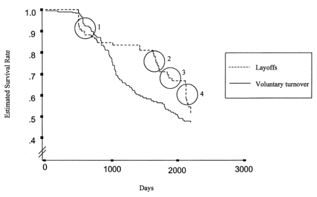

NOTE: figure/graphic rendered as an image from the PDF; its content is not machine-readable text. Caption (if any) follows as the next block.

**Figure 1.** Product limit estimates of the survival function.

991 DETERMINANTS OF VOLUNTARY TURNOVER AND LAYOFFS AFTER A MERGER

JOURNAL OF MANAGEMENT, VOL. 26, NO. 5, 2000

Page 16

Table 3 reports the results of the proportional hazards model of employees who voluntarily left and employees who were laid-off. Analyses were performed using time-dependent Cox regression in SPSS (Norusˇis, 1994a). As can be seen we estimated several models based on the five categories of variables. We begin by briefly examining the separate hierarchical models before finishing on the fully integrated model as shown in equation 5. Deriving from the various theoretical perspectives, we expect the fully integrated model to better fit the data (Mueller & Price, 1990).

*Voluntary Turnover*

*Layoffs*

Considering the downsized employees, the demographic variables of age (*B* 5 .050, *p* , .05) and full-time (*B* 5 .479, *p* , .05) were found to be significantly related (see equation 1 in Table 3). Older employees who were full-time were more likely to be laid-off. In contrast to our expectations, no economic variables (controlling for demographic variables) were observed to have significant effects (see equation 2). Only the sociological variables of coworker support (*B* 5 2.724, *p* , .001) and work overload (*B* 5 2.358, *p* , .05) were significant controlling for the two preceding categories (see equation

992 R.D. IVERSON AND J.A. PULLMAN

JOURNAL OF MANAGEMENT, VOL. 26, NO. 5, 2000

Page 17

**Table 3.** Cox Proportional Hazards Model of Voluntary Turnover and Layoffs

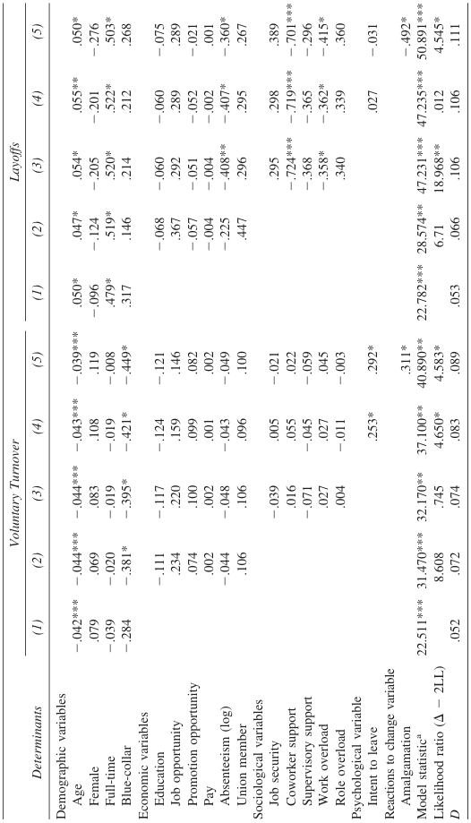

NOTE: figure/graphic rendered as an image from the PDF; its content is not machine-readable text. Caption (if any) follows as the next block.

**text found inside the figure**

*Determinants*

*Voluntary Turnover Layoffs*

*(1) (2) (3) (4) (5) (1) (2) (3) (4) (5)*

Demographic variables

Age 2.042*** 2.044*** 2.044*** 2.043*** 2.039*** .050* .047* .054* .055** .050*

Female .079 .069 .083 .108 .119 2.096 2.124 2.205 2.201 2.276 Full-time 2.039 2.020 2.019 2.019 2.008 .479* .519* .520* .522* .503*

Blue-collar 2.284 2.381* 2.395* 2.421* 2.449* .317 .146 .214 .212 .268

Economic variables

Education 2.111 2.117 2.124 2.121 2.068 2.060 2.060 2.075 Job opportunity .234 .220 .159 .146 .367 .292 .289 .289

Promotion opportunity .074 .100 .099 .082 2.057 2.051 2.052 2.021 Pay .002 .002 .001 .002 2.004 2.004 2.002 .001

Absenteeism (log) 2.044 2.048 2.043 2.049 2.225 2.408** 2.407* 2.360* Union member .106 .106 .096 .100 .447 .296 .295 .267

Sociological variables

Job security 2.039 .005 2.021 .295 .298 .389

Coworker support .016 .055 .022 2.724*** 2.719*** 2.701*** Supervisory support 2.071 2.045 2.059 2.368 2.365 2.296 Work overload .027 .027 .045 2.358* 2.362* 2.415* Role overload .004 2.011 2.003 .340 .339 .360

Psychological variable

Intent to leave .253* .292* .027 2.031 Reactions to change variable

Amalgamation .311* 2.492* Model statistica 22.511*** 31.470*** 32.170** 37.100** 40.890** 22.782*** 28.574** 47.231*** 47.235*** 50.891*** Likelihood ratio (D 2 2LL) 8.608 .745 4.650* 4.583* 6.71 18.968** .012 4.545* *D* .052 .072 .074 .083 .089 .053 .066 .106 .106 .111

a Global chi-square (null hypothesis that all of the coefficients are 0).

* *p* , .05 ** *p* , .01 *** *p* , .001

993 DETERMINANTS OF VOLUNTARY TURNOVER AND LAYOFFS AFTER A MERGER

JOURNAL OF MANAGEMENT, VOL. 26, NO. 5, 2000

Page 18

3—with absenteeism becoming significant: *B* 5 2.408, *p* , .01). When coworker support was low and job performance was perceived not to be excessive, employees were more likely to be retrenched. Turning to the psychological variable of intent to leave (see equation 4), we found no effect with downsizing (controlling for the demographic, economic, and sociological variables). Finally, the fully integrated model (see equation 5) in which the change variable of amalgamation was entered along with the previous four categories of variables displayed some notable findings. Employees who felt conditions had deteriorated at the hospital since the amalgamation were more likely to be retrenched (*B* 5 2.492, *p* , .05). Older employees were more likely to be downsized (*B* 5 .050, *p* , .05), as were those who were full-time (*B* 5 .503, *p* , .05), had less absenteeism (*B* 5 2.360, *p* , .05), experienced low support from coworkers (*B* 5 2.701, *p* , .001) and felt the work load was acceptable (*B* 5 2.415, *p* , .05). The final model explained a modest but significant proportion of variance in the layoffs hazard rates (*D* 5 .111).

*Differential Effects*

Table 4 displays the differences between voluntary turnover and layoffs for each of the five categories of determinants and the findings of the discriminant function analysis. Wilks’ Lambdas and univariate F-ratios demonstrate that significant differences were observed for the variables of age, full-time, blue-collar, education, coworker support, and amalgamation. In terms of the discriminant function, a significant relationship was found between the determinants and the voluntary turnover and layoff groups (Wilks’ Lambda 5 .745; x<sup>2</sup> (6) 5 45.689, *p* , .0001). The eigenvalue (.343) and canonical correlation (.505) affirmed the differential effects of the determinants. For example, around 25% of the variability in the discriminant scores was attributed to between-group differences (.505<sup>2</sup> 5 .255). As can be seen in Table 4, six of the determinants were significant discriminators (see standardized coefficients). In order of discriminant strength, older employees were more likely to be laid-off than resign, as were blue-collar workers. This is also occurred when co-worker support was low, employees worked full-time, the hospital amalgamation was considered to be negative, and work load was perceived to be acceptable. Turning to Table 5, the success rate of the discriminant function was 81%, which was 17.39% higher than that expected by chance alone. Hence, the prediction accuracy of the discriminant function was supported. The implications of these along with the event history analysis findings will be outlined in the *Discussion* section.

#### **Discussion**

This study has contributed to our understanding of the turnover process involved in a hospital undergoing repeated downsizing following a merger. Employing determinants derived from the disciplines of economics, sociology, and psychology, and demographic and reactions to change variables, we predicted employees who resigned and those who were laid-off. We did this by using the statistical procedure of event history analysis, which allowed us to follow em-

994 R.D. IVERSON AND J.A. PULLMAN

JOURNAL OF MANAGEMENT, VOL. 26, NO. 5, 2000

Page 19

**Table 4.** Summary of Stepwise Discriminant Analysis Resultsa

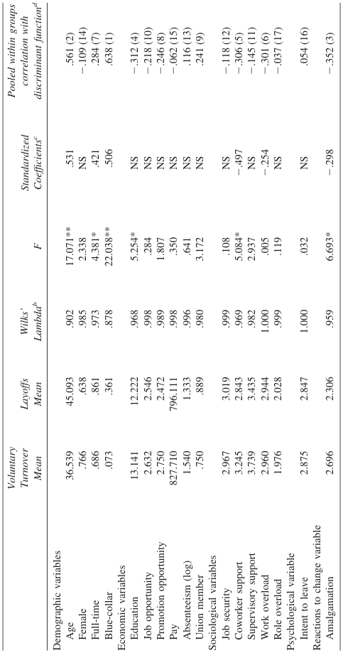

NOTE: figure/graphic rendered as an image from the PDF; its content is not machine-readable text. Caption (if any) follows as the next block.

**text found inside the figure**

*Voluntary*

*Turnover*

*Mean Layoffs*

*Mean Wilks’*

*Lambdab F Standardized*

*Coefficientsc*

*Pooled within groups*

*correlation with*

*discriminant functiond*

Demographic variables

Age 36.539 45.093 .902 17.071** .531 .561 (2)

Female .766 .638 .985 2.338 NS 2.109 (14) Full-time .686 .861 .973 4.381* .421 .284 (7)

Blue-collar .073 .361 .878 22.038** .506 .638 (1)

Economic variables

Education 13.141 12.222 .968 5.254* NS 2.312 (4) Job opportunity 2.632 2.546 .998 .284 NS 2.218 (10) Promotion opportunity 2.750 2.472 .989 1.807 NS 2.246 (8) Pay 827.710 796.111 .998 .350 NS 2.062 (15) Absenteeism (log) 1.540 1.333 .996 .641 NS .116 (13)

Union member .750 .889 .980 3.172 NS .241 (9)

Sociological variables

Job security 2.967 3.019 .999 .108 NS 2.118 (12) Coworker support 3.245 2.843 .969 5.084* 2.497 2.306 (5) Supervisory support 3.739 3.435 .982 2.937 NS 2.145 (11) Work overload 2.960 2.944 1.000 .005 2.254 2.301 (6) Role overload 1.976 2.028 .999 .119 NS 2.037 (17) Psychological variable

Intent to leave 2.875 2.847 1.000 .032 NS .054 (16)

Reactions to change variable

Amalgamation 2.696 2.306 .959 6.693* 2.298 2.352 (3)

a Layoffs coded as 1 and voluntary turnover coded as 0.

b Lambda ranges from 0 to 1, with a value of 1 indicating no difference in group means.

c ‘NS’ indicates that variable was not swept into the discriminant function because it failed to meet the mimimum significance inclusion criterion.

d Numbers in parentheses () indicate the relative order of absolute magnitude.

* *p* , .05 ** *p* , .001

995 DETERMINANTS OF VOLUNTARY TURNOVER AND LAYOFFS AFTER A MERGER

JOURNAL OF MANAGEMENT, VOL. 26, NO. 5, 2000

Page 20

ployees over a five year period. Moreover, discriminant function analysis indicated differences in determinants between these two forms of turnover. Our findings have a number of theoretical and practical implications for the study of turnover.

Consistent with the original work of Price (1975), our findings suggest that layoffs and voluntary turnover are not homogenous. That is, they cannot be explained by the same set of determinants. This was reinforced by the significant negative correlation (*r* 5 2.313) between the two. The only common factors were the demographic variable of age (Barrick et al., 1994; Somers, 1996) and the reactions to change variable of amalgamation (Lee & Mitchell, 1994; Lee et al., 1996, 1999). However, these were found to have differential effects for the two types of turnover in both the event history and discriminant function analyses. Older employees who responded negatively to the amalgamation were more likely to be downsized, while younger employees who responded positively were more likely to resign. The respective findings for age were consistent with our costcutting (Barrick et al., 1994) and sunk costs (Meyer & Allen, 1997) explanations. In relation to amalgamation, the positive association with voluntary turnover seems puzzling. One plausible explanation is that employees who initially thought changes had been for the better, over time considered there be a deterioration in conditions. The hospital has undergone four separate downsizing exercises (i.e., shocks) since the administration of the survey which may account for this (as shown in Figure 1). Sugalski et al. (1995) note that survivors’ workload and stress generally increase during restructuring. Thus, the motivation of employees to resign.

Our results indicate that employee layoffs are determined by demographic, economic, and sociological variables, as well as the previously discussed reactions to change variable. As cost considerations underpinned the merger and downsizing of the hospital, we anticipated the targeting of demographic and economic variables to be a prominent concern. In contrast, the decision to voluntary leave is a consequence of demographic, psychological, and reactions to change variables. These latter two sets of variables were consistent with our expectations, although the sociological rather than the demographic factors were argued to be more salient. We found no evidence for the psychological variable of intent to leave for layoffs or any of the economic and sociological variables for voluntary turnover (see Table 6 for a review of the original hypotheses). Follow-

**Table 5.** Discriminant Classification Summary Table<sup>a</sup>

|  |  | PredictedGroup |  |
| --- | --- | --- | --- |
| ActualGroup | VoluntaryTurnover | Layoffs | Total |
| Voluntaryturnover | 131 | 9 | 140 |
|  | (936%) . | (64%) . | (10000%) . |
| Layoffs | 26 | 18 | 44 |
|  | (591%) . | (409%) . | (10000%) . |

NOTE: table converted from PDF layout to HTML text; cell boundaries are reconstructed. See PDF if exact alignment matters.

a Overall percent of correctly classified cases was (149/184) 5 81.00%. Proportional chance criterion 5 p2 1 (1 2 p)<sup>2</sup> where p is the proportion of voluntary turnover: (.761)<sup>2</sup> 1 (.239)<sup>2</sup> 5 63.61%.

996 R.D. IVERSON AND J.A. PULLMAN

JOURNAL OF MANAGEMENT, VOL. 26, NO. 5, 2000

Page 21

ing the merger, perhaps employees engaging in problem-focused coping behavior (e.g., pursuing alternative employment) (Bennet et al., 1995) were not targeted for redundancy. In the case of voluntary turnover, it would appear that the structural or job related factors are not as important as other reasons for employees deciding to stay or leave the hospital (Mueller et al., 1994; Price & Mueller, 1986). These issues warrant additional research. Nonetheless, we were better able to predict employees who were laid-off (*D* 5 .111) than those who resigned (*D* 5 .089), with the former having six and the latter having four significant determinants. This has distinct implications for workforce reduction strategies.

In terms of the demographic variables, full-time employees were more likely to be made redundant. We argued that as full-time employees were more costly to employ than part-time employees they would be targeted for downsizing. This was reflected by the significant correlation with pay (*r* 5 .344, *p* , .05). Employment status was also a significant discriminator between employees who were laid-off and those who resigned. As hypothesized, white-collar employees rather than their blue-collar counterparts were more likely to resign. This finding may be explained by the hospital’s focus on increasing efficiencies in support services which predominately comprised blue-collar employees. As previously

**Table 6.** Summary of Support for Original Hypotheses

|  | VoluntaryTurnover |  |  | Layoffs |
| --- | --- | --- | --- | --- |
|  | Hypothesis | Result | Hypothesis | Result |
| Demographicvariables |  |  |  |  |
| Age | 2 | Support | 1 | Support |
| Female | 1 | Reject | 2 | Reject |
| Full -time | 2 | Reject | 1 | Support |
| Blue-collar | 2 | Support | 1 | Reject |
| Economicvariables |  |  |  |  |
| Education | 1 | Reject | 2 | Reject |
| Jobopportunity | 1 | Reject | 2 | Reject |
| Promotionopportunity | 2 | Reject | 2 | Reject |
| Pay | 2 | Reject | 1 | Reject |
|  |  |  |  | (Reject though , 2 |
| Absenteeism(log) | 1 | Reject | 1 | found) |
| Unionmember | 2 | Reject | 2 | Reject |
| Sociologicalvariables |  |  |  |  |
| Jobsecurity | 2 | Reject | 2 | Reject |
| Coworkersupport | 2 | Reject | 2 | Support |
| Supervisorysupport | 2 | Reject | 2 | Reject |
| Workoverload | 1 | Reject | 2 | Support |
| Roleoverload | 1 | Reject | 1 | Reject |
| Psychologicalvariable |  |  |  |  |
| Intenttoleave | 1 | Support | 1 | Reject |
| Reactionstochangevariable |  | (Reject though1 , |  |  |
| Amalgamation | 2 | found) | 2 | Support |

NOTE: table converted from PDF layout to HTML text; cell boundaries are reconstructed. See PDF if exact alignment matters.

997 DETERMINANTS OF VOLUNTARY TURNOVER AND LAYOFFS AFTER A MERGER

JOURNAL OF MANAGEMENT, VOL. 26, NO. 5, 2000

Page 22

outlined, the hospital had inadvertently engendered a package culture whereby some employees requested to be made redundant only on the condition they would receive a package. This was a major disincentive for blue-collar employees to voluntary leave. White-collar employees, in contrast, perceived there to be greater job opportunities in the labor market (*r* 5 .121, *p* , .05) which helps explain their resignation (Price & Mueller, 1986). Further, these employees were more likely to voluntarily leave than be retrenched from the hospital.

Turning to the economic variables, absenteeism predicted layoffs. Counter to our expectations that following the merger employees feeling insecure would be motivated to attend work, absenteeism had a negative impact on downsizing. That is, employees displaying avoidable absence behavior were less likely to be retrenched. Bycio (1992) using data from 46 articles in a meta-analysis of the relationship between individual performance (e.g., supervisory ratings/rankings, non-rating quality indices, and non-rating promotional indices) and absenteeism concluded that on average “ . . . frequently absent employees also tend to be poor performers” (p. 204). Hence, this finding would seem to be at odds with the hospital’s basic aim of cutting costs and increasing efficiencies. Surprisingly, other factors apart from absenteeism would appear to be more important in targeting employees for retrenchment. As previously discussed, the hospital may have unwittingly eliminated positions containing employees with low absenteeism rates. Applying mixed redundancy approaches (i.e., targeting positions and individuals) as those employed at the hospital sometimes have unintended consequences of removing functional and not dysfunctional employees.

In relation to the sociological variables, downsizing also occurs when coworker support is low. This determinant had differential effects for the two forms of turnover. In the present study we found coworker support to be related with lower absenteeism (*r* 5 2 .173, *p* , .05). Hence, coworker support is associated with factors (e.g., reduced costs) that are functional for organizations. We argued that this type of support may reflect help-seeking coping behavior, enabling employees to deal with stressful situations (Armstrong-Strassen, 1998). Conversely, from the stress of the hospital merger, it is feasible that downsized employees may have blamed other employees with whom they interacted for their situation (Leana & Feldman, 1990). That is, they attempt to cope by attributing responsibility to others (e.g., loafing). This may account for the present finding, where downsized employees perceived that coworkers could not be relied upon when things got difficult on the job, were not willing to listen to job related problems, and were not helpful in getting the job done. Finally, it is also plausible that if employees feel a sense of ‘powerlessness’ to avert the perceived threat of redundancy (Greenhalgh & Rosenblatt, 1984) they may compete with rather than support each other (Cameron, 1994). Employees may consider this as the only course of action open to them in attempting to survive the merger.

Work overload, another sociological variable, also had a negative impact on layoffs. That is, the greater the effort required to perform the job, the less the likelihood of being made redundant. Importantly, the discriminant function analysis also revealed that by working harder, employees displayed a lower probability of being laid-off than resigning. Greenhalgh and Rosenblatt (1984) suggest

998 R.D. IVERSON AND J.A. PULLMAN

JOURNAL OF MANAGEMENT, VOL. 26, NO. 5, 2000

Page 23

that employees instead of being complacent may actually increase their work load when facing the threat of job loss. Employees’ ability to add-value to the organization reduces their perceived job insecurity. Surprising, we observed no relationship between work overload and absenteeism. Hackett and Bycio’s (1996) research suggests, that absence can be interpreted as a coping mechanism for employees experiencing stressful situations. The occasional absences enable employees to maintain their physical and psychological well-being. In the present study, employees rather than reacting to the merger by being absent, reacted by working harder.

The psychological variable of intent to leave was found to have an impact on voluntary turnover. There is an abundance of evidence to support that employees first display a propensity to withdraw before resigning (e.g., Hom & Griffeth, 1995). Interestingly, intent to leave also displayed a positive relationship with downsizing (*r* 5 .107, *p* , .05), although it was not significant in the event history analysis.

Yet some care must be taken in regards to the generalizability of the findings. First, the data comes from one hospital which predominately comprised unionized, female, white-collar employees. Second, the hospital in offering certain employees generous severance packages (voluntary and targeted) may have used this as a form of dismissal in managing out poor performers. Further, this would have been much more attractive for older, full-time, high-wage employees due to the superior redundancy package. Third, although we employed a design that measured the various determinants prior to the risk of turnover, these variables were collected at one point in time. This raises concerns regarding their effects. Fourth, the hospital downsized four different times during the study period. Unfortunately, these shocks were not accompanied by repeated surveys of the determinants. Finally, it was not possible to decompose the direct and indirect effects of the determinants on turnover. This may have shed more light on the decision process of employees.

Despite these limitations, our study has provided important insights on how employees cope with organizational shocks such as mergers and repeated downsizing. We identified organizational weaknesses of employing mixed redundancy approaches. For example, employees with higher absence levels were less likely to be retrenched. In addition, an often not cited problem of “package culture” was engendered. This financial incentive became a major demotivator for employees wanting to leave but not targeted for redundancy by the hospital. Importantly, we observed the differential effects of the various economic, sociological, psychological, demographic, and change variables. The utility of fully integrated models, as well as the advantage of applying event history analysis in turnover research (Morita et al., 1993; Somers, 1996; Somers & Birnbaum, 1999) was observed. In a climate of workforce reduction, our exploratory work provides the foundation for researchers to further disentangle the factors that predict employees who voluntarily leave and those who are laid-off. Future research should attempt to focus much more attention on predicting rather than just describing the downsizing process of employees if we are to better understand the antecedents and consequences of such organizational shocks.

999 DETERMINANTS OF VOLUNTARY TURNOVER AND LAYOFFS AFTER A MERGER

JOURNAL OF MANAGEMENT, VOL. 26, NO. 5, 2000

Page 24

#### **Notes**

1. An earlier version of this paper was presented at the 1999 Annual Academy of Management Meetings in Chicago. The research reported in this paper was supported by an Australian Research Council Grant SG7923485 awarded to Stephen J. Deery and Roderick D. Iverson and a Faculty of Economics and Commerce Research Grant awarded to Roderick D. Iverson. The authors would like to thank Craig Littler, Robert Vecchio, Lea Waters, and the two anonymous reviewers of this journal for their helpful comments on earlier versions of this article. 2. The hospital also offered voluntary departure packages which were across-the-board. Employees were asked to submit expressions of interest in writing as to their potential surplus in the hospital. This package encompassed an initial redundancy payment of AUD$10,000 for every full-time equivalent staff member. Employees were entitled to 2 weeks of pay per every year of service up to a maximum of 15 years. They were also entitled to an additional 4 weeks of pay. Included in the package were accrued annual leave and long-service leave. The maximum severance pay to any employee comprised AUD$10,000, 34 weeks pay, and accrued annual and long-service leave. The certified agreement between the hospital and unions stipulated that employees could not be re-employed by a Victorian public sector agency for a period of three years and hospital contractor for 18 months. Although the package was termed voluntary, pressure was informally exerted on some employees to take this package due to their likelihood of being targeted for retrenchment. In this situation turnover would be considered to be more involuntary than voluntary (Campion, 1991). Given the increased cost, a minority of employees were offered voluntary departure packages (personal communication with HR manager). 3. Mishra, Spreitzer, and Mishra (1998) note that laid-off employees in the US generally receive a severance package of one week’s pay for every year of service, accrued vacation, sick pay, supplemental unemployment benefits, and outplacement benefits. 4. The certified “Change Agreement” between the unions and hospital states that employees shall be offered a retrenchment package when their position has been declared redundant and suitable redeployment opportunities (in terms of classification, grade, and income) do not exist. Although technically this is done in accordance with the Workplace Relations Act 1996 (previously the Industrial Relations Act 1988) that protects against termination of employment being harsh, unjust or unreasonable and that it does not contravene SECT 170CK of the Act (e.g., dismissal based on sex, age, family responsibilities, union membership), we base our demographic predictions on the literature (e.g., Barrick et al., 1994). 5. Sheridan (1992) notes that *D* is similar to the *R*<sup>2</sup> value employed in regression models: *D* 5 x<sup>2</sup>/ (n 2 K 1 x<sup>2</sup>), where n 5 sample size and K 5 number of variables (Hintze, 1989).

#### **References**

Abelson, M. A. 1987. Examination of avoidable and unavoidable turnover. *Journal of Applied Psychology*, 72:

382–386. Allison, P. D. 1984. *Event history analysis*. Beverly Hills, CA: Sage. Armstrong–Strassen, M. 1998. The effect of gender and organizational level on how survivors cope with

organizational downsizing. *Journal of Applied Behavioral Science*, 34(2): 125–142. Australian Bureau of Statistics. 1998. *Retrenchment and redundancy, Australia, July 1997* (Cat. No. 6266.0). Bagozzi, R. P. & Yi, Y. 1988. On the evaluation of structural equation models. *Academy of Marketing Science*,

16: 74–94. Barling, J., Fullagar, C., & Kelloway, E. K. 1992. *The union and its members: A psychological approach*. New

York: Oxford University Press. Barrick, M. R., Mount, M. K., & Strauss, J. P. 1994. Antecedents of involuntary turnover due to a reduction in

force. *Personnel Psychology*, 47: 515–535. Becker, G. 1964. *Human capital*. New York: Columbia University Press. Becker, G. 1975. *Human capital* (2d ed.). New York: National Bureau of Economic Research. Bencivenga, D. 1997. Employers & workers come to terms. *HRMagazine*, 42(6): 90–93. Bennet, N., Martin C. L., Bies, R. J, & Brockner, J. 1995. Coping with a layoff: A longitudinal study of victims.

*Journal of Management*, 21(6): 87–117. Bentler, P. M. 1990. Comparative fit indexes in structural models. *Psychological Bulletin*, 107: 238–246. Blau, P. M. 1960. A theory of social integration. *American Journal of Sociology*, 65: 545–556. Brockner, J. 1988. The effects of work layoffs on survivors: Research theory and practice. *Research in*

*Organizational Behavior*, 10: 213–255. Brooke, P. P., & Price, J. L. 1989. The determinants of employee absenteeism: An empirical test of a causal

model. *Journal of Occupational Psychology*, 62: 1–19. Browne, M. W., & Cudeck, R. 1993. Alternative ways of assessing model fit. In K. A. Bollen and J. S. Long

(Eds), *Testing structural equation models*: 136–162. Newbury Park, CA: Sage.

1000 R.D. IVERSON AND J.A. PULLMAN

JOURNAL OF MANAGEMENT, VOL. 26, NO. 5, 2000

Page 25

Budros, A. 1997. The new capitalism and organizational rationality: The adoption of downsizing programs,

1979–1994. *Social Forces*, 76(1): 229–250. Burton, J. F., & Parker, J. E. 1969. Inter-industry variations in voluntary labor mobility. *Industrial Labor*

*Relations Review*, 22: 199–216. Bycio, P. 1992. Job performance and absenteeism: A review and meta-analysis. *Human Relations*, 45(2):

193–220. Bycio, P., Hackett, R. D., & Alvares, K. M. 1990. Job performance and turnover: A review and meta-analysis.

*Applied Psychology: An International Review*, 39(1): 47–76. Cameron, K. S. 1998. Strategic organizational downsizing: An extreme case. *Research in Organizational*

*Behavior*, 20: 185–229. Cameron, K. S. 1994. Strategies for successful organizational downsizing. *Human Resource Management*, 33(2):

189–211. Cameron, K. S., Freeman, S. J., & Mishra, A. K., 1991. Best practices in white-collar downsizing: Managing

contradictions. *Academy of Management Executive*, 5(3): 57–73. Campion, M. A. 1991. Meaning and measurement of turnover: Comparison of Alternative measures and

recommendations for research. *Journal of Applied Psychology*, 76(2): 199–212. Cascio,W. F. 1993. Downsizing: What do we know? What have we learned? *Academy of Management*

*Executive*, 7(1): 95–104. Cascio, W. F., Young, C. E., & Morris, J, R. 1997. Financial consequences of employment change decisions in

major U.S. corporations. *Academy of Management Journal*, 40(5): 1175–1189. Chadwick-Jones, J. K., Nicholson, N. & Brown, C. A. 1982. *Social psychology of absenteeism*. New York:

Praeger. Cohen, A. 1999. Turnover among professionals: A longitudinal study of American lawyers. *Human Resource*

*Management*, 38(1): 61–75. Constable, J. K. 1983. The effects of social support and the work environment upon burnout among nurses.

(Unpublised dissertation). The University of Iowa. Cotton, J. L., & Tuttle, J. M. 1986. Employee turnover: A meta-analysis and review with implications for

research. *Academy of Management Review*, 11: 55–70. Cronbach, L. J. 1951. Coefficient alpha and the internal structure of tests. *Psychometrika*, 16: 297–334. Dalton, D. R., Todor, W. D., & Krackhardt, D. M. 1982. Turnover overstated: A functional taxonomy. *Academy*

*of Management Review*, 7: 117–123. Dawkins, P., Littler, C. R., Valenzuela, M. R., & Jensen, B. 1999. *The contours of restructuring & downsizing*

*in Australia*. Parkville, Australia: The University of Melbourne, Melbourne Institute of Applied Economics and Social Research. Dillon, S. 1997. Putting some sense into downsizing. *The Age*, June 3, A15. Ebadan, G., & Winstanley, D. 1997. Downsizing, delayering, and careers—The survivor’s perspective. *Human*

*Resource Management Journal*, 7(1): 79–91. Erwin, P. J. & Iverson, R. D. 1994. Strategies in absence management. *Asia Pacific Journal of Human*

*Resources*, 32(3): 13–32. Freeman, R. B. 1980. The exit-voice tradeoff in the labor market: Unionism, job tenure, quits, and separations.

*Quarterly Journal of Economics*, 94: 643–673. Freeman, S. J. 1994. Organizational downsizing as convergence or reorientation: Implications for human

resource management. *Human Resource Management*, 33(2): 213–238. Gerbing, D. W., & Anderson, J. C. 1993. Monte Carlo evaluations of goodness-of-fit indices for structural

equation models. In K. A. Bollen and J. S. Long (Eds) *Testing structural equation models* (pp. 40–65). Newbury Park, CA: Sage. Greenhalgh, L., & Rosenblatt, Z. 1984. Job insecurity: Toward conceptual clarity. *Academy of Management*

*Review*, 9(3): 438–448. Hackett, R. D., & Bycio, P. 1996. An evaluation of employee absenteeism as a coping mechanism among

hospital nurses. *Journal of Occupational and Organizational Psychology*, 69: 327–338. Hammer, T. H. & Landau, J. 1981. Methodological issues in the use of absence data. *Journal of Applied*

*Psychology*, 66: 574–580. Herzberg, F. 1968. *Work and the Nature of Man*. London: Granada. Hintze, J. L. 1989. *SOLO statistical system: Version 3.0 survival analysis*. Los Angeles: BMDP Statistical

Software. Hom, P. W. & Griffeth, R. W. 1995. *Employee turnover*. Ohio: South-Western College. House, J. S. 1981. *Work stress and social support*. Reading, MA: Addison–Wesley. Iverson, R. D. 1996. Employee acceptance of organizational change: The role of organizational commitment.

*International Journal of Human Resource Management*, 7(1): 121–148. Iverson, R. D. & Buttigieg, D. 1999. Affective, normative, and continuance commitment: Can the ‘right kind’

of commitment be managed? *Journal of Management Studies*, 36(3): 307–333.

1001 DETERMINANTS OF VOLUNTARY TURNOVER AND LAYOFFS AFTER A MERGER

JOURNAL OF MANAGEMENT, VOL. 26, NO. 5, 2000

Page 26

Iverson, R. D., Deery, S. J., & Erwin, P. J. 1995. Absenteeism in the health services sector: A causal model and

intervention strategies. In P. Riedel and A. Preston (Eds), *Managing absenteeism: Analysing and preventing labour absence*. Canberra: AGPS. Iverson, R. D. & Erwin, P. J. 1997. Predicting occupational injury: The role of affectivity. *Journal of*

*Occupational and Organizational Psychology*, 70: 113–128. Iverson, R. D., & Kuruvilla, S. 1995. Antecedents of union loyalty: The influence of individual dispositions and

organisational context. *Journal of Organizational Behavior*, 16: 557–582. Iverson, R. D., Olekalns, M., & Erwin, P. J. 1998. Affectivity, organizational stressors and absenteeism: A causal

model of burnout and it’s consequences. *Journal of Vocational Behavior*, 52(1): 1–23. Iverson, R. D. & Roy, P. 1994. A causal model of behavioral commitment: Evidence from a study of Australian

blue-collar employees. *Journal of Management*, 20(1): 15–41. Johns, G. 1978. Attitudinal and nonattitudinal predictors of two forms of absence from work. *Organizational*

*Behaviour and Human Performance*, 22: 431–444. Jo¨reskog, K. G. & So¨rborn, D. 1993a. *LISREL 8: user’s reference guide*. Chicago: Scientific Software

International. Jo¨reskog, K. G. & So¨rbom, D. 1993b. *PRELIS 2: User’s Reference Guide*. Chicago: Scientific Software

International. Judge, T. A., Martocchio, J. J., & Thorensen, C. J. 1997. Five-factor model of personality and employee absence.

*Journal of Applied Psychology*, 82(2): 745–755. Kets de Vries, M. F. R. & Balazs, K. 1997. The downside of downsizing. *Human Relations*, 50(1): 11–51. La Rocco, J. M., Pugh, W. M., & Gunderson, K. E. 1977. Identifying determinants of retention decisions.

*Personnel Psychology*, 30: 199–215. Leana, C. R., & Feldman, D. C. 1990. Individual responses to job loss: Empirical findings from two field studies.

*Human Relations*, 43: 115–1181. Lee, T. W., & Mitchell, T. R. 1994. An alternative approach: The unfolding model of voluntary employee

turnover. *Academy of Management Review*, 19: 51–89. Lee, T. W., Mitchell, T. R., Holtom, B. C., McDaniel, L. S., & Hill, J. W. 1999. An unfolding model of voluntary

turnover: A replication and extension. *Academy of Management Journal*, 42(4): 450–462. Lee, T. W., Mitchell, T. R., Wise, L., & Fireman, S. 1996. An unfolding model of voluntary employee turnover.

*Academy of Management Journal*, 39(1): 5–36. Littler, C. R, Bramble, T. & Dunford, R. 1996. Downsizing: A disease or a cure. *The Australian Human*

*Resource Magazine*, HR Monthly August, 8–12. Littler, C. R., Dunford, R, Bramble, T. & Hede, A. 1997. The dynamics of downsizing in Australia and New

Zealand. *Asia Pacific Journal of Human Resources*, 35(1): 65–82. Luthans, B. C., & Sommer, S. M. 1999. The impact of downsizing on workplace attitudes: Differing reactions

to managers and staff in a health care organization. *Group & Organization Management*, 24(1): 46–70. Maertz, C. P., Jr. & Campion, M. A. 1998. 25 years of voluntary turnover research: A review and critique. In

C. L. Cooper and I. T. Roberstson (Eds) *International Review of Industrial and Organizational Psychology* (Vol. 3, pp. 49–81. NY: John Wiley & Sons. March, J. G., & Simon, H. A. 1958. *Organizations*. New York: Wiley. Martin, T. N. 1979. A contextual model of employee turnover intentions. *Academy of Management Journal*, 22:

313–324. Meyer, J. P. & Allen, N. J. 1997. *Commitment in the workplace: Theory, research, and application*. Thousand

Oaks, CA: Sage. Michaels, C. E., & Spector, P. E. 1982. Causes of employee turnover: A test of the Mobley, Griffeth, Hand and

Meglino Model. *Journal of Applied Psychology*, 67: 53–59. Mishra, K. E., Spreitzer, G. M., & Mishra, A. K. 1998. Preserving employee morale during downsizing. *Sloan*

*Management Review*, Winter: 83–95. Mitra, A., Jenkins, Jr. G. D., & Gupta, N. 1992. A meta-analytic review of the relationship between absence and

turnover. *Journal of Applied Psychology*, 77: 879–889. Mobley, W. H. 1982. *Employee turnover: Causes, consequences and control*. Reading, MA: Addison–Wesley. Mobley, W. H. 1977. Intermediate linkages in the relationship between job satisfaction and employee turnover.

*Journal of Applied Psychology*, 62: 237–237. Mobley, W. H., Griffeth, R. W., Hand, H. H., & Meglino, B. M. 1979. Review and conceptual analysis of the

employee turnover process. *Psychological Bulletin*, 86: 493–522. Mone, M. 1994. Relationships between self-concepts, aspirations, emotional responses and intent to leave a

downsizing organization. *Human Resource Management*, 33(2): 261–279. Morita, J. G., Lee, T. W., & Mowday, R. T. 1993. The regression-analog to survival analysis: A selected

application to turnover research. *Academy of Management Journal*, 36: 1430–1464. Mueller, C. W., Price, J. L., Boyer, M., & Iverson, R. D. 1994. Employee attachment and noncoercive conditions

of work: The case of dental hygienists. *Work and Occupations*, 21(2): 179–212.

1002 R.D. IVERSON AND J.A. PULLMAN

JOURNAL OF MANAGEMENT, VOL. 26, NO. 5, 2000

Page 27

Mueller, C. W., & Price, J. L. 1990. Economic, psychological, and sociological determinants of voluntary

turnover. *Journal of Behavioral Economics*, 19: 321–335. Mueller, C. W., Price, J. L., & Iverson, R. D. 1989. An event history analysis of voluntary and involuntary

turnover. *Paper presented at 49th Annual Meeting of the Academy of Management*. Washington, D.C. Norusˇis, M. J. 1994a. *SPSS Advanced Statistics Guide*. Chicago, IL: SPSS. Norusˇis, M. J. 1994b. *SPSS Professional Statistics*. Chicago, IL: SPSS. Oldham, G. R., Kulik, C. T., Stepina, L. P. & Ambrose, M. L. 1986. Relations between situational factors and

the comparative referents used by employees. *Academy of Management Journal*, 29: 599–608. Porter, L. W. & Steers, R. M. 1973. Organizational, work and personal factors in employee turnover and

absenteeism. *Psychological Bulletin*, 80: 151–176. Porter, L. W., Steers, R. M., Mowday, R. T., & Boulian, P. V. 1974. Organizational commitment, job satisfaction

and turnover among psychiatric technicians. *Journal of Applied Psychology*, 59: 603–609. Price, J. L. 1975. A theory of turnover. In B.O. Pettman (Ed.), *Labor turnover and retention* (pp. 51–75). New

York: Wiley. Price, J. L. 1977. *The study of turnover*. Ames: Iowa State University Press. Price, J. L. & Mueller, C. W. 1986. *Absenteeism and turnover of hospital employees*. Greenwich, CT: JAI Press. Price, J. L. & Mueller, C. W. 1981. *Professional turnover: The case of nurses*. New York: SP Medical and

Scientific. Rhodes, S. R. & Steers, R. M. 1990. *Managing employee absenteeism*. J. P. Wanous (Ed.), Reading, MA:

Addison-Wesley. Rosse´, J. G. & Miller, H. E. 1984. Relationship between absenteeism and other employee behaviors. In P. S.

Goodman & R. S. Atkin (Eds.), *Absenteeism: New approaches to understanding, measuring, and managing employee absence*. San Francisco: Jossey-Bass. Shaw, J. D., Delery, J. E., Jenkins, G. D., & Gupta, N. 1998. An organizational-level analysis of voluntary and

involuntary turnover. *Academy of Management Journal*, 41(5): 511–525. Somers, M. J. 1996. Modelling employee withdrawal behaviour over time: A study of turnover using survival

analysis. *Journal of Occupational and Organizational Psychology*, 69: 315–326. Somers, M. & Birnbaum, D. 1999. Survival versus traditional methodologies for studying employee turnover:

Differences, divergences and directions for future research. *Journal of Organizational Behavior*, 20: 273–284. Stumpf, S. A., & Dawley, P. K. 1981. Predicting voluntary and involuntary turnover using absenteeism and

performance indices. *Academy of Management Journal*, 24: 148–163. Sugalski, T. D., Manzo, L. S., & Meadows, J. L. 1995. Resource link establishing the employment relationship

in an era of downsizing. *Human Resource Management*, 34(3): 389–403. Uchitelle, L. & Kleinfield, N. R. 1996. On the battlefield of business, millions of casualties. *New York Times*,

March 3(1): 14–16. Trevor, C., Gerhart, B., & Boudreau, J. W. 1997. Voluntary turnover and job performance: Curvilinearity and

the moderating influences of salary growth and promotions. *Journal of Applied Psychology*, 82(1): 44–61. Tuma, N. B. & Hannan, M. T. 1984. *Social dynamics*. New York: Academic Press. Viscusi, W. K. 1979. *Employment hazards*. Cambridge: Harvard University Press. Vroom, V. H. 1964. *Work and motivation*. New York: Wiley. Williamson, O. E. 1975. *Markets and hierarchies: Analysis and antitrust implications*. New York: The Free

Press. Yamaguchi, K. 1991. *Event history analysis*. Newbury Park, CA: Sage.

1003 DETERMINANTS OF VOLUNTARY TURNOVER AND LAYOFFS AFTER A MERGER

JOURNAL OF MANAGEMENT, VOL. 26, NO. 5, 2000